# Practical Machine Learning Project

zv

19 February 2016

## Summary

In this project, data from the Weight Lifting Exercise (http://groupware.les.inf.puc-rio.br/har (see the section on the Weight Lifting Exercise Dataset) is used. This dataset contains data the goal was be to use data from accelerometers on the belt, forearm, arm, and dumbell of 6 participants. These participants were asked to perform barbell lifts correctly and incorrectly in 5 different ways. The goal of this project is to predict the manner in which they did the exercise.

## Load data and required libraries

For data modeling and prediction, *caret* and *rattle* has been used.

```r
library(caret)
library(rattle)
```

Training and testing datasets are downloaded first. If datasets already exist in working directory, then download is skipped. Dataset files are read into two data frames.

```r
urlTraining <- "https://d396qusza40orc.cloudfront.net/predmachlearn/pml-training.csv"
urlTesting <- "https://d396qusza40orc.cloudfront.net/predmachlearn/pml-testing.csv"
fileTraining <- "./pml-training.csv"
fileTesting <- "./pml-testing.csv"

if (!file.exists(fileTraining)) {
        download.file(urlTraining, fileTraining, method="curl")
}

if (!file.exists(fileTesting)) {
        download.file(urlTesting, fileTesting, method="curl")
}

dataTraining <- read.csv(fileTraining, header=TRUE, sep=",", na.strings = c("NA","#DIV/0!",""))
dataTesting <- read.csv(fileTesting, header=TRUE, sep=",", na.strings = c("NA","#DIV/0!",""))
```

Training data set contains *classe* variable, which is used fro predictions and testing dataset will be used at the end of this exercise. It contains 20 cases for which we need to predict *classe*. Testing dataset doesn’t contain *classe*.

To validate training model, the training dataset needs to be split to training and cross-validation data set. But before that we need to clean the training data set and apply transformations to testing data set as well.

## Data Cleaning

Initially, all columns with NA valuse are removed from training dataset. Additionally, only columns with names containing strings “_belt“,”_forearm“,”_arm" and “dumbbell” are kept, all others are removed. After transformations are done on training data set, the same transformations are done on testing dataset.

```r
classe <- dataTraining$classe
dataTraining <- dataTraining[,colSums(is.na(dataTraining)) == 0]
colsInclude <- grepl("_belt|_forearm|_arm|_dumbbell", names(dataTraining))
dataTraining <- dataTraining[,colsInclude]
predictorCols <- names(dataTraining)
dataTesting <- dataTesting[, predictorCols]
```

Finally, there are 52 columns in both datasets. In training dataset, column *classe* will be added so we could build model and predict based on it.

## Prepare training and cross validation sets

Training dataset is split, so 70% of records is used for training the model and 30% is used for cross-validation.

```r
dataTraining <- cbind(classe, dataTraining)
set.seed(817)
inTrain <- createDataPartition(dataTraining$classe, p=0.7, list=FALSE)
dataTrainingT<- dataTraining[inTrain, ]
dataTrainingCV <- dataTraining[-inTrain,]
```

## Decision Tree

Using training data, we will create a new prediction model using decision tree.

```r
fitModDT <- train(classe~., data=dataTrainingT, method="rpart")
fitModDT
```

```
## CART
##
## 13737 samples
##    52 predictor
##     5 classes: 'A', 'B', 'C', 'D', 'E'
##
## No pre-processing
## Resampling: Bootstrapped (25 reps)
## Summary of sample sizes: 13737, 13737, 13737, 13737, 13737, 13737, ...
## Resampling results across tuning parameters:
##
##   cp          Accuracy   Kappa       Accuracy SD  Kappa SD
##   0.03509307  0.5078928  0.36068512  0.02365757   0.03745234
##   0.06004815  0.4259532  0.22681001  0.06388924   0.10640444
##   0.11606144  0.3317812  0.07495171  0.04211308   0.06253275
##
## Accuracy was used to select the optimal model using  the largest value.
## The final value used for the model was cp = 0.03509307.
```

As you can see, the accuracy of the model is actually not really high, 51% for cost-complexity parameter 0.0351.

Let’s plot the decision tree for our model:

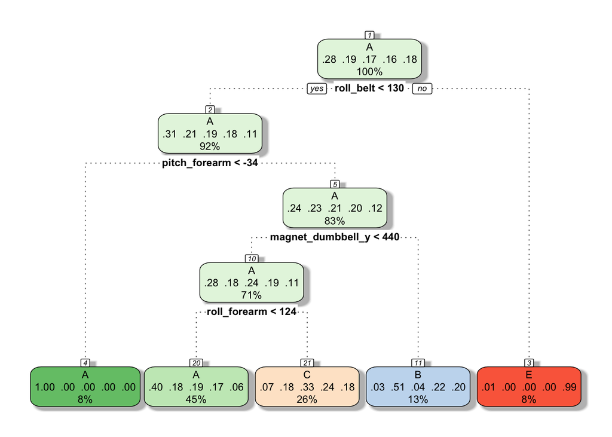

```r
fancyRpartPlot(fitModDT$finalModel, sub="")
```

## Tuned Decision Tree

To improve decision tree model, we could tune it. The tuneLength function can be used to evaluate a broader set of models. The default resampling scheme for rpart is the bootstrap. In the model below, we are using 3 times repeated 10–fold cross–validation instead.

```r
fitModDT <- train(classe~., data=dataTrainingT, method="rpart", tuneLength=10, trControl=trainControl(method = "repeatedcv", repeats = 3))
fitModDT
```

```
## CART
##
## 13737 samples
##    52 predictor
##     5 classes: 'A', 'B', 'C', 'D', 'E'
##
## No pre-processing
## Resampling: Cross-Validated (10 fold, repeated 3 times)
## Summary of sample sizes: 12363, 12363, 12363, 12364, 12363, 12365, ...
## Resampling results across tuning parameters:
##
##   cp          Accuracy   Kappa      Accuracy SD  Kappa SD
##   0.01230801  0.7108580  0.6325000  0.01801111   0.02267738
##   0.01441020  0.6787781  0.5940686  0.01557090   0.01879179
##   0.01724138  0.6597520  0.5710969  0.01373078   0.01657462
##   0.01891974  0.6473058  0.5567400  0.01423668   0.01752367
##   0.02105584  0.6357568  0.5425059  0.01422471   0.01774036
##   0.02283593  0.5907610  0.4768595  0.05020599   0.07405405
##   0.02807446  0.5312636  0.3885282  0.01135534   0.01538996
##   0.03509307  0.4990425  0.3452208  0.01253552   0.01673793
##   0.06004815  0.4368708  0.2437065  0.06151158   0.10333962
##   0.11606144  0.3378490  0.0817781  0.03869110   0.05903540
##
## Accuracy was used to select the optimal model using  the largest value.
## The final value used for the model was cp = 0.01230801.
```

As you can see, the “tuned” model shows much better accuracy then the model without tuning, 71%.

Additionally, our decision tree model can be presented graphically:

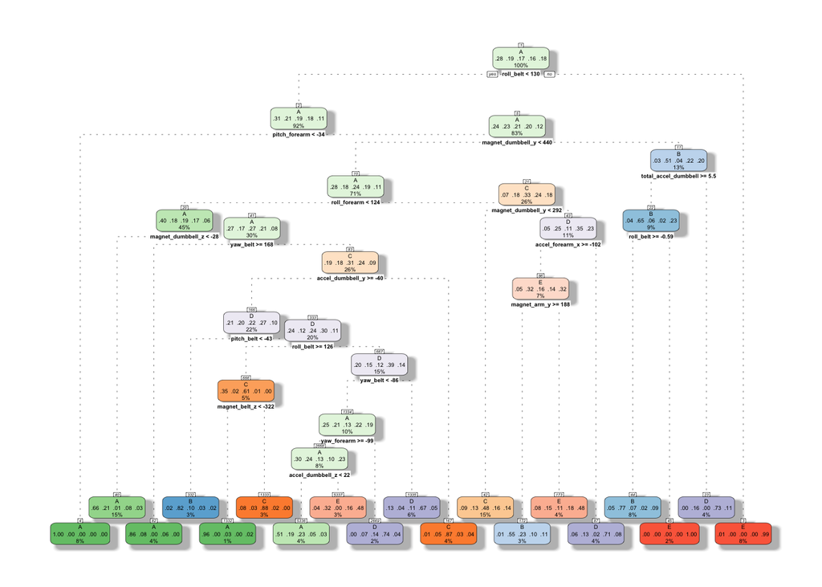

```r
fancyRpartPlot(fitModDT$finalModel, sub="")
```

Decision tree graph is a bit more complex, isn’t it?

We can now run prediction using previously separated (30% of training dataset) cross validation dataset and compare predicted results with actual values of *classe*.

```r
predictDT_CV <- predict(fitModDT, dataTrainingCV)
confusionMatrix(dataTrainingCV$classe, predictDT_CV)
```

```
## Confusion Matrix and Statistics
##
##           Reference
## Prediction    A    B    C    D    E
##          A 1437   30  116   54   37
##          B  248  571  138   74  108
##          C   76   86  775   61   28
##          D  100   33  128  623   80
##          E   34   65  154   61  768
##
## Overall Statistics
##
##                Accuracy : 0.7093
##                  95% CI : (0.6975, 0.7208)
##     No Information Rate : 0.322
##     P-Value [Acc > NIR] : < 2.2e-16
##
##                   Kappa : 0.6308
##  Mcnemar's Test P-Value : < 2.2e-16
##
## Statistics by Class:
##
##                      Class: A Class: B Class: C Class: D Class: E
## Sensitivity            0.7583  0.72739   0.5912   0.7136   0.7522
## Specificity            0.9406  0.88863   0.9451   0.9320   0.9354
## Pos Pred Value         0.8584  0.50132   0.7554   0.6463   0.7098
## Neg Pred Value         0.8912  0.95491   0.8897   0.9492   0.9473
## Prevalence             0.3220  0.13339   0.2228   0.1483   0.1735
## Detection Rate         0.2442  0.09703   0.1317   0.1059   0.1305
## Detection Prevalence   0.2845  0.19354   0.1743   0.1638   0.1839
## Balanced Accuracy      0.8495  0.80801   0.7681   0.8228   0.8438
```

Prediction using cross validation set actually confirms what we actually expected, the model is about 70% accurate.

## Random Forest

To build better prediction model we are going to use Random Forest algorithm. We will use 5-fold cross-validation resampling method (10-fold cross-validation turned out to be much more computationally intensive and last quite long, but results are not that different). We are also setting number of trees (ntree) parameter to 100.

```r
set.seed(817)
fitModRF <- train(classe~., data=dataTrainingT, method = "rf", trControl=trainControl(method="cv",5), ntree=100)
```

Model plot will show that the best accuracy when split is made when 27 (mtry) features/predictors are used. In that case, accuracy is 99%.

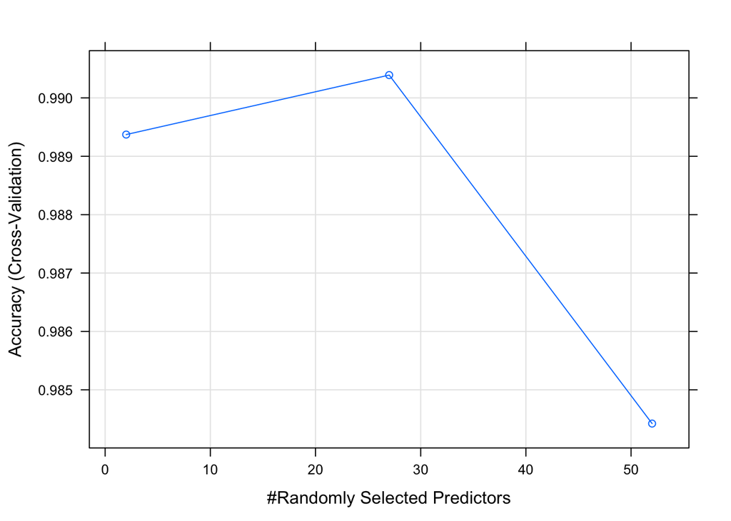

```r
plot.train(fitModRF)
```

We can see the details in finalModel:

```r
fitModRF
```

```
## Random Forest
##
## 13737 samples
##    52 predictor
##     5 classes: 'A', 'B', 'C', 'D', 'E'
##
## No pre-processing
## Resampling: Cross-Validated (5 fold)
## Summary of sample sizes: 10990, 10991, 10989, 10989, 10989
## Resampling results across tuning parameters:
##
##   mtry  Accuracy   Kappa      Accuracy SD  Kappa SD
##    2    0.9893719  0.9865546  0.002031928  0.002570361
##   27    0.9903910  0.9878445  0.001108988  0.001403207
##   52    0.9844223  0.9802936  0.003538719  0.004475576
##
## Accuracy was used to select the optimal model using  the largest value.
## The final value used for the model was mtry = 27.
```

Let’s run prediction for our cross validation data set and check confusion matrix in which we compere predicted values with cross validation valuse of *classe*.

```r
predictRF_CV <- predict(fitModRF, dataTrainingCV)
confusionMatrix(dataTrainingCV$classe, predictRF_CV)
```

```
## Confusion Matrix and Statistics
##
##           Reference
## Prediction    A    B    C    D    E
##          A 1670    2    1    0    1
##          B    5 1131    3    0    0
##          C    0    7 1017    2    0
##          D    0    0   11  952    1
##          E    0    0    2    0 1080
##
## Overall Statistics
##
##                Accuracy : 0.9941
##                  95% CI : (0.9917, 0.9959)
##     No Information Rate : 0.2846
##     P-Value [Acc > NIR] : < 2.2e-16
##
##                   Kappa : 0.9925
##  Mcnemar's Test P-Value : NA
##
## Statistics by Class:
##
##                      Class: A Class: B Class: C Class: D Class: E
## Sensitivity            0.9970   0.9921   0.9836   0.9979   0.9982
## Specificity            0.9990   0.9983   0.9981   0.9976   0.9996
## Pos Pred Value         0.9976   0.9930   0.9912   0.9876   0.9982
## Neg Pred Value         0.9988   0.9981   0.9965   0.9996   0.9996
## Prevalence             0.2846   0.1937   0.1757   0.1621   0.1839
## Detection Rate         0.2838   0.1922   0.1728   0.1618   0.1835
## Detection Prevalence   0.2845   0.1935   0.1743   0.1638   0.1839
## Balanced Accuracy      0.9980   0.9952   0.9909   0.9977   0.9989
```

We can be very satisfied with the final results. Out of sample error for the model is 0.59% (Accuracy = 99%).

## Applying testing data set on Random Forest model

Finally, we have to predict on the testing dataset and submit 20 answers to the final quiz.

```r
predictTestRF <- predict(fitModRF, dataTesting)
predictTestRF
```

```
##  [1] B A B A A E D B A A B C B A E E A B B B
## Levels: A B C D E
```